# Atividade Prática 6 — Respostas

Econometria Aplicada à Finanças  
Mestrado Profissional em Administração

Autor

Paulo Aragão Daldegan

Data de Publicação

14 de setembro de 2026

## Questão 1

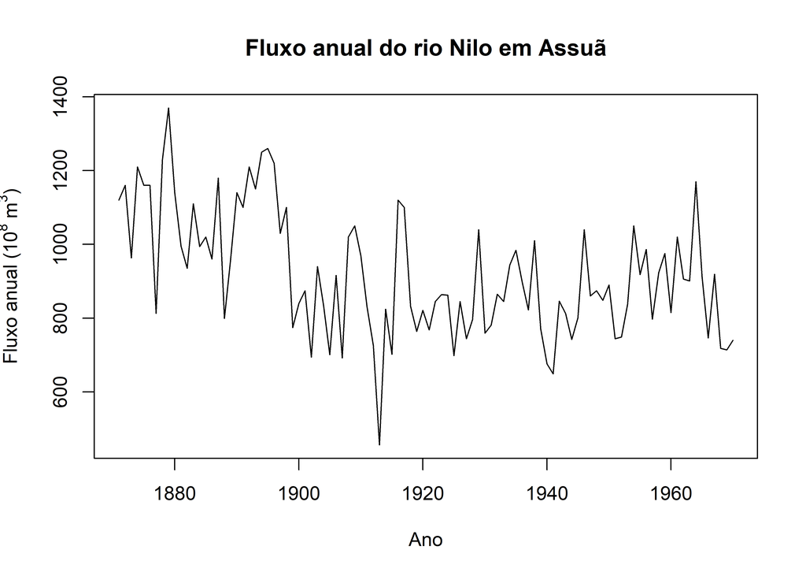

```r
# Carrega a série anual do fluxo do rio Nilo
# disponível no pacote datasets.
data("Nile", package = "datasets")

# Representa a série para examinar possíveis mudanças
# de nível ao longo do tempo.
plot(
  Nile,
  type = "l",
  xlab = "Ano",
  ylab = expression("Fluxo anual (" * 10^8 * " m"^3 * ")"),
  main = "Fluxo anual do rio Nilo em Assuã"
)
```

```r
# Estima um modelo com apenas intercepto para
# representar o nível médio da série.
modelo_nilo <- lm(Nile ~ 1)
```

### **a)**

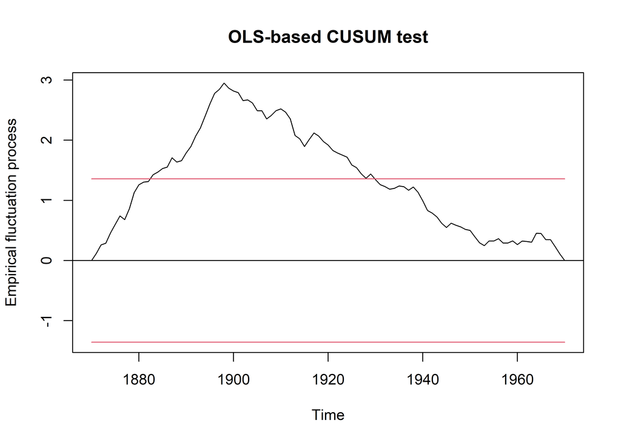

```r
# Calcula o processo OLS-CUSUM para avaliar a
# estabilidade da média.
cusum_nilo <- strucchange::efp(
  formula(modelo_nilo),
  type = "OLS-CUSUM"
)

# Representa o processo OLS-CUSUM com os
# limites críticos de 5%.
plot(cusum_nilo, alpha = 0.05)
```

```r
# Calcula a estatística e o valor-p do
# teste OLS-CUSUM.
resultado_cusum <- strucchange::sctest(cusum_nilo)

# Exibe a estatística e o valor-p do teste.
resultado_cusum
```

```
    OLS-based CUSUM test

data:  cusum_nilo
S0 = 2.95, p-value = 0.000000054
```

**NotaSua resposta**

Pelo gráfico, podemos observar que o limite crítico é ultrapassado entre 1880 e 1900, permanecendo fora do limite até o intervalo entre 1920 e 1940, trazendo indícios visuais de não haver estabilidade.Além disso, é possível constatar uma mudança de direção das somas cumulativas dos resíduos estimados próximo ao ano de 1900. A estatística de teste foi de 2,95, com um valor-p baixíssimo, abaixo do nível de significância de 5%, portanto há evidência contra a hipótese nula de estabilidade na média de fluxo anual do rio Nilo, indicando uma possível quebra estrtural e sendo consistente com o observado no gráfico.

### **b)**

```r
# Calcula as estatísticas F para as divisões candidatas da amostra,
# utilizando trimming de 15% nas extremidades.
estatisticas_f <- strucchange::Fstats(
  formula(modelo_nilo),
  from = 0.15
)

# Aplica o teste supF para uma quebra com
# localização desconhecida.
resultado_supf <- strucchange::sctest(
  estatisticas_f,
  type = "supF"
)

# Exibe a estatística e o valor-p do teste.
resultado_supf
```

```
    supF test

data:  estatisticas_f
sup.F = 75.9, p-value = 0.00000000000000022
```

```r
# Localiza a divisão associada ao maior
# valor das estatísticas F.
quebra_nilo <- strucchange::breakpoints(estatisticas_f)

# Exibe a localização estimada da quebra.
quebra_nilo
```

```
     Optimal 2-segment partition:

Call:
breakpoints.Fstats(obj = estatisticas_f)

Breakpoints at observation number:
28

Corresponding to breakdates:
1898
```

**NotaSua resposta**

A estatística sup.F foi de 75,9 com um p-valor abaixo de 0,05, sendo estatisticamente significativo ao nível de 5%. Assim, rejeita-se a hipótese nula de estabilidade, indicando que há evidência de uma única mudança abrupta com ponto de quebra desconhecido. O ano associado a quebra da amostra foi 1898, na observação 28, sendo também o ano de término do primeiro regime, com o segundo regime começando com o ano subsequente, em 1899. A localização da quebra encontrada (1898) é compatível com o contexto histórico apresentado, referente à construção da primeira barragem de Assuã no final do século XIX. Essa evidência por si só não pode afirmar que a construção da barragem causou a mudança, podendo haver outros fatores. O teste supF também constatou uma quebra estrutural, assim como os indícios visuais e estatísticos do teste OLS-CUSUM, mas a partir dele, podemos localizar o ponto onde houve a quebra e o ano com maior precisão.